# rapport_Eilat

L. Bastin

2023-06-21

## Importation des librairies

```r
library(dplyr)
library(ggplot2)
library(tidyr)
library(tidyft)
library(ggfortify)
library(gridExtra)
library(vegan)
library(ggcorrplot)
library(tseries)
library(ggh4x)
library(ggpubr)
library(pheatmap)
```

## Définition de fonctions

```r
NumberOf = function(class) {
  # Returns the number of different families present in a Radiolarian class
  return(length(unique(TAX$Family[TAX$Class == class])))
}
```

```r
GetPeriod = function(samples) {
  # Generates a period column assigning a period to each sample of the dataframe
  m <- as.numeric(substr(samples, 5, 6))
  p <- paste(periods$period[match(m, periods$month_id)], "_20", substr(samples, 3, 4), sep = "")

  p <- factor(p, levels = c("M_2_2020", "M_1_2021", "B_2021", "S_2021",
                            "M_2_2021", "M_1_2022", "B_2022", "S_2022"))

  return(p)
}
```

```r
GetMonth = function(samples) {
  # Generates a month id column
  m <- substr(samples, 5, 6)
  m[m != "10"] <- gsub("0", "", m[m != "10"])

  m <- factor(m, levels = c("1", "2", "3", "4", "5", "6", "7", "8", "9", "10", "11", "12"))

  return(m)
}
```

## Importation des jeux de données

```r
TAX <- read.csv("Data/TAX_pr2_Radiolaria_GoA.csv")
META <- read.csv("Data/META_Radiolaria_GoA.csv")
OTU <- read.csv("Data/OTU_Radiolaria_GoA.csv")
```

Un identifiant unique d’OTU de la forme OTU_n est rajouté au tableau TAX, et les variables non étudiées sont retirées du tableau META.

```r
TAX <- cbind(OTU_name = paste("OTU_", sprintf("%03d", seq(1, 531, 1)), sep = ""), TAX)
META <- subset(META, select = -c(phaeo, Si_TIN, Si_P, TIN_P, air_temp, solar_radiation))
```

Tableau TAX :

| OTU_name | X | Kingdom | Phylum | Class | Order | Family | Genus | Species |
| --- | --- | --- | --- | --- | --- | --- | --- | --- |
| OTU_001 | 33dd16e1e5cd0e02577e8c1930735825 | Rhizaria | Radiolaria | Polycystinea | Spumellaria | Astrosphaeridae | Astrosphaeridae_X | Astrosphaeridae_X_sp. |
| OTU_002 | 762dab9668e6601f3289a3a7ab3cb148 | Rhizaria | Radiolaria | RAD-B | RAD-B_X | RAD-B_X_Group-IVe | RAD-B_X_Group-IVe_X | RAD-B_X_Group-IVe_X_sp. |
| OTU_003 | 4c5ebd93c9e2188340d5ff6b0b8aa391 | Rhizaria | Radiolaria | RAD-B | RAD-B_X | Taxopodida | Sticholonche | Sticholonche_sp. |
| OTU_004 | 29b0d77651e016a5cb5c1ad1dca245bd | Rhizaria | Radiolaria | Polycystinea | Spumellaria | Astrosphaeridae | Cladococcus | Cladococcus_scoparius |
| OTU_005 | bb247aeed30daaea5914dcd7a9eb9951 | Rhizaria | Radiolaria | RAD-B | RAD-B_X | RAD-B_X_Group-II | RAD-B_X_Group-II_X | RAD-B_X_Group-II_X_sp. |
| OTU_006 | adc7ae2b646e5759948b975feac3285a | Rhizaria | Radiolaria | Polycystinea | Spumellaria | Astrosphaeridae | Astrosphaera | Astrosphaera_hexagonalis |

Tableau META :

| sample_id | year | month | day | date | sample | depth | temp | salinity | chl | PO4 | Silica | TIN | wind_speed | PAR | UV |
| --- | --- | --- | --- | --- | --- | --- | --- | --- | --- | --- | --- | --- | --- | --- | --- |
| A_201125_1 | 20 | 11 | 25 | 25/11/2020 | a | surface | 25.4452 | 40.5090 | 0.2349598 | 0.03 | 0.32 | 0.2501435 | 3.3 | 366 | 17 |
| A_201125_2 | 20 | 11 | 25 | 25/11/2020 | b | surface | 25.4452 | 40.5090 | 0.2349598 | 0.03 | 0.32 | 0.2501435 | 3.3 | 366 | 17 |
| A_201216_1 | 20 | 12 | 16 | 16/12/2020 | a | surface | 24.8394 | 40.8433 | 0.2283674 | 0.04 | 0.31 | 0.2900367 | 0.9 | 97 | 9 |
| A_201216_2 | 20 | 12 | 16 | 16/12/2020 | b | surface | 24.8394 | 40.8433 | 0.2283674 | 0.04 | 0.31 | 0.2900367 | 0.9 | 97 | 9 |
| A_201230_1 | 20 | 12 | 30 | 30/12/2020 | a | surface | 23.8268 | 40.9096 | 0.2413977 | 0.02 | 0.43 | 0.4335441 | 6.0 | 180 | 11 |
| A_201230_2 | 20 | 12 | 30 | 30/12/2020 | b | surface | 23.8268 | 40.9096 | 0.2413977 | 0.02 | 0.43 | 0.4335441 | 6.0 | 180 | 11 |

Tableau OTU :

| X | A_201125_1 | A_201125_2 | A_201216_1 | A_201216_2 | A_201230_1 | A_201230_2 | A_210107_1 |
| --- | --- | --- | --- | --- | --- | --- | --- |
| 33dd16e1e5cd0e02577e8c1930735825 | 0 | 0 | 21 | 8 | 24 | 13 | 0 |
| 762dab9668e6601f3289a3a7ab3cb148 | 25 | 31 | 30 | 31 | 0 | 0 | 0 |
| 4c5ebd93c9e2188340d5ff6b0b8aa391 | 0 | 0 | 16 | 11 | 620 | 681 | 339 |
| 29b0d77651e016a5cb5c1ad1dca245bd | 0 | 13 | 6 | 6 | 5 | 3 | 0 |
| bb247aeed30daaea5914dcd7a9eb9951 | 142 | 103 | 275 | 112 | 1147 | 869 | 164 |
| adc7ae2b646e5759948b975feac3285a | 0 | 22 | 0 | 0 | 0 | 0 | 0 |

```r
months_equi <- data.frame("month" = c(1, 2, 3, 4, 5, 6, 7, 8, 9, 10, 11, 12),
                          "month_str" = c("Jan", "Feb", "Mar", "Apr", "May", "Jun",
                                          "Jul", "Aug", "Sep", "Oct", "Nov", "Dec"))
periods <- data.frame("month_id" = c(1, 2, 3, 4, 5, 6, 7, 8, 9, 10, 11, 12),
                      "period" = c("M_1", "M_1", "B", "B", "S", "S", "S", "S", "S", "M_2", "M_2", "M_2"))

period_labs <- c("M", "M", "B", "S", "M", "M", "B", "S")
names(period_labs) <- c("M_2_2020", "M_1_2021", "B_2021", "S_2021",
                        "M_2_2021", "M_1_2022", "B_2022", "S_2022")
```

Le tableau `periods` :

- M : période de mixing (octobre-février)
- B : période de bloom (mars-avril)
- S : période de stratification (mai-septembre)

| month_id | 1 | 2 | 3 | 4 | 5 | 6 | 7 | 8 | 9 | 10 | 11 | 12 |
| --- | --- | --- | --- | --- | --- | --- | --- | --- | --- | --- | --- | --- |
| period | M_1 | M_1 | B | B | S | S | S | S | S | M_2 | M_2 | M_2 |

```r
OTU_to_group <- data.frame(OTU = TAX$OTU_name, Class = TAX$Class, Order = TAX$Order, group = "")
OTU_to_group$group <- OTU_to_group$Class
OTU_to_group[OTU_to_group$Class == "Polycystinea", ]$group <- OTU_to_group[OTU_to_group$Class == "Polycystinea", ]$Order
```

## Création de palettes de couleur

Une palette pour les Ordres avec un gradient de bleus pour les acanthaires et un gradient d’oranges pour les groupes environnementaux. Une palette pour les groupes qui reprend les couleurs des Ordres, et une pour les profondeurs (surface/dcm).

```r
library(RColorBrewer)
```

```r
order_palette <- c(colorRampPalette(brewer.pal(9, "Blues"))(10),
                   "red",
                   colorRampPalette(brewer.pal(3, "Oranges"))(4),
                   "black")

names(order_palette) <- c("Acantharea_1", "Acantharea_2", "Acantharea_3", "Acantharea_4",
                          "Acantharea_A", "Acantharea_B", "Acantharea_C", "Acantharea_D",
                          "Acantharea_E", "Acantharea_F", "Nassellaria", "RAD-A_X",
                          "RAD-B_X", "RAD-C_X", "Radiolaria_XX", "Spumellaria")

group_palette <- c("#084D96", "red", colorRampPalette(brewer.pal(3, "Oranges"))(4), "black")
names(group_palette) <- c("Acantharea", "Nassellaria", "RAD-A", "RAD-B", "RAD-C", "Radiolaria_X", "Spumellaria")

depth_palette <- c("#07b1f2", "#54d326")
names(depth_palette) <- c("surface", "dcm")
```

## Description des jeux de données

```r
summ <- data.frame("nb_OTUs" = nrow(OTU),
                  "max_abund" = max(OTU[-1]),
                  "mean_abund" = mean(as.matrix(OTU[-1])),
                  "nb_samples" = ncol(OTU[-1]),
                  "nb_days" = length(unique(substr(colnames(OTU[-1]), 3, 8))),
                  "nb_variables" = ncol(META[8:16]),
                  "nb_families" = length(unique(TAX$Family)),
                  "nb_Acantharea" = NumberOf("Acantharea"),
                  "nb_Polycystinea" = NumberOf("Polycystinea"),
                  "nb_RAD-A" = NumberOf("RAD-A"),
                  "nb_RAD-B" = NumberOf("RAD-B"),
                  "nb_RAD-C" = NumberOf("RAD-C"),
                  "nb_Radiolaria_X" = NumberOf("Radiolaria_X"))
```

```
##   nb_OTUs max_abund mean_abund nb_samples nb_days nb_variables nb_families
## 1     531      1885   1.944805         94      42            9          63
##   nb_Acantharea nb_Polycystinea nb_RAD.A nb_RAD.B nb_RAD.C nb_Radiolaria_X
## 1            23              25        5        7        2               1
```

## Normalisation du tabeau d’OTU

Chaque colonne est normalisée individuellement entre 0 et 1.

```r
OTU_norm <- mapply('/', OTU[-1], colSums(OTU[, -1]))
OTU_norm <- cbind(OTU[1], OTU_norm)
```

| X | A_201125_1 | A_201125_2 | A_201216_1 | A_201216_2 | A_201230_1 | A_201230_2 | A_210107_1 |
| --- | --- | --- | --- | --- | --- | --- | --- |
| 33dd16e1e5cd0e02577e8c1930735825 | 0.0000000 | 0.0000000 | 0.0145935 | 0.0087051 | 0.0086831 | 0.0053520 | 0.0000000 |
| 762dab9668e6601f3289a3a7ab3cb148 | 0.0106293 | 0.0124748 | 0.0208478 | 0.0337323 | 0.0000000 | 0.0000000 | 0.0000000 |
| 4c5ebd93c9e2188340d5ff6b0b8aa391 | 0.0000000 | 0.0000000 | 0.0111188 | 0.0119695 | 0.2243126 | 0.2803623 | 0.4734637 |
| 29b0d77651e016a5cb5c1ad1dca245bd | 0.0000000 | 0.0052314 | 0.0041696 | 0.0065288 | 0.0018090 | 0.0012351 | 0.0000000 |
| bb247aeed30daaea5914dcd7a9eb9951 | 0.0603741 | 0.0414487 | 0.1911049 | 0.1218716 | 0.4149783 | 0.3577604 | 0.2290503 |
| adc7ae2b646e5759948b975feac3285a | 0.0000000 | 0.0088531 | 0.0000000 | 0.0000000 | 0.0000000 | 0.0000000 | 0.0000000 |

## Création d’un tableau d’abondance

Le tableau d’abondance contient une partie de la classification taxonomique, l’échantillon, sa date et période associée, ainsi que la valeur d’abondance normalisée correspondant.

```r
abund <- cbind("class" = TAX$Class[which(OTU_norm$X == TAX$X)],
               "order" = TAX$Order[which(OTU_norm$X == TAX$X)],
               OTU_norm[-1])

abund <- gather(abund, "sample", "value", -c(1, 2))
```

| class | order | sample | value |
| --- | --- | --- | --- |
| Polycystinea | Spumellaria | A_201125_1 | 0.0000000 |
| RAD-B | RAD-B_X | A_201125_1 | 0.0106293 |
| RAD-B | RAD-B_X | A_201125_1 | 0.0000000 |
| Polycystinea | Spumellaria | A_201125_1 | 0.0000000 |
| RAD-B | RAD-B_X | A_201125_1 | 0.0603741 |
| Polycystinea | Spumellaria | A_201125_1 | 0.0000000 |

Les lignes avec la même taxonomie et le même échantillon sont regroupées entre elles (l’ordre est similaire mais pas forcément la famille par exemple).

```r
abund <- abund %>%
  group_by(sample, class, order) %>%
  summarize(across(value, sum))
```

| sample | class | order | value |
| --- | --- | --- | --- |
| A_201125_1 | Acantharea | Acantharea_1 | 0.0025510 |
| A_201125_1 | Acantharea | Acantharea_2 | 0.1092687 |
| A_201125_1 | Acantharea | Acantharea_3 | 0.0085034 |
| A_201125_1 | Acantharea | Acantharea_4 | 0.0901361 |
| A_201125_1 | Acantharea | Acantharea_A | 0.0000000 |
| A_201125_1 | Acantharea | Acantharea_B | 0.0000000 |

Des colonnes contenant la profondeur, le mois, la période et l’année sont rajoutées.

```r
abund$depth <- "surface"
abund$depth[substring(abund$sample, 10, 12) == "dcm"] <- "dcm"

abund$month <- GetMonth(abund$sample)
abund$period <- GetPeriod(abund$sample)

abund$year <- paste("20", substr(abund$sample, 3, 4), sep = "")
```

| sample | class | order | value | depth | month | period | year |
| --- | --- | --- | --- | --- | --- | --- | --- |
| A_201125_1 | Acantharea | Acantharea_1 | 0.0025510 | surface | 11 | M_2_2020 | 2020 |
| A_201125_1 | Acantharea | Acantharea_2 | 0.1092687 | surface | 11 | M_2_2020 | 2020 |
| A_201125_1 | Acantharea | Acantharea_3 | 0.0085034 | surface | 11 | M_2_2020 | 2020 |
| A_201125_1 | Acantharea | Acantharea_4 | 0.0901361 | surface | 11 | M_2_2020 | 2020 |
| A_201125_1 | Acantharea | Acantharea_A | 0.0000000 | surface | 11 | M_2_2020 | 2020 |
| A_201125_1 | Acantharea | Acantharea_B | 0.0000000 | surface | 11 | M_2_2020 | 2020 |

Les échantillons sont regroupés par mois, ordre et profondeur avec la moyenne des valeurs d’abondance.

```r
abund <- abund %>%
  group_by(order, month, year, period, depth) %>%
  summarize(across(value, mean))
```

| order | month | year | period | depth | value |
| --- | --- | --- | --- | --- | --- |
| Acantharea_1 | 1 | 2021 | M_1_2021 | surface | 0.0066039 |
| Acantharea_1 | 1 | 2022 | M_1_2022 | surface | 0.0099770 |
| Acantharea_1 | 2 | 2021 | M_1_2021 | surface | 0.0035348 |
| Acantharea_1 | 2 | 2022 | M_1_2022 | surface | 0.0524999 |
| Acantharea_1 | 3 | 2021 | B_2021 | surface | 0.0563411 |
| Acantharea_1 | 3 | 2022 | B_2022 | surface | 0.0163692 |

Des valeurs d’abondance nulles sont rajoutées pour inclure dans le graphique les mois de juillet et septembre où aucun échantillon n’a été prélevé.

```r
for (i in unique(abund$order)) {
  abund <- rbind(abund, data.frame(order = i, month = "7", year = "2021",
                                   period = "S_2021", value = 0, depth = "all"))

  abund <- rbind(abund, data.frame(order = i, month = "9", year = "2021",
                                   period = "S_2021", value = 0, depth = "all"))
}
```

La colonne `period` est ordonnée en facteurs et une colonne qui contient le nom de mois pour l’abscisse du graphique est rajoutée.

```r
abund$period <- factor(abund$period, levels = names(period_labs))

abund$month_str <- months_equi$month_str[match(abund$month, months_equi$month)]
abund$month_str <- factor(abund$month_str, levels = months_equi$month_str)
```

| order | month | year | period | depth | value | month_str |
| --- | --- | --- | --- | --- | --- | --- |
| Acantharea_1 | 1 | 2021 | M_1_2021 | surface | 0.0066039 | Jan |
| Acantharea_1 | 1 | 2022 | M_1_2022 | surface | 0.0099770 | Jan |
| Acantharea_1 | 2 | 2021 | M_1_2021 | surface | 0.0035348 | Feb |
| Acantharea_1 | 2 | 2022 | M_1_2022 | surface | 0.0524999 | Feb |
| Acantharea_1 | 3 | 2021 | B_2021 | surface | 0.0563411 | Mar |
| Acantharea_1 | 3 | 2022 | B_2022 | surface | 0.0163692 | Mar |

## Barplot d’abondance relative

L’abondance relative de tous les ordres de Radiolaires est représentée en moyenne pour chaque mois. Les couleurs sont similaires pour chaque groupe (les acanthaires en bleu et les groupes environnementaux en orange). Chaque mois est associé à une année et une période représentées en haut du graphique.

```r
PlotAbundance = function(data, depth_, title) {
  ggplot(data = subset(data, depth %in% depth_), aes(x = month_str, fill = order, y = value)) +
    geom_bar(stat = "identity") +
    facet_nested(cols = vars(year, period), space = "free", scales = "free", labeller = labeller(period = period_labs)) +
    guides(fill = guide_legend(ncol = 1)) +
    theme(legend.key.size = unit(0.4, 'cm'),
          legend.text = element_text(size = 10),
          axis.title.x = element_text(size = 8),
          axis.text.x = element_text(size = 10, angle = 80, hjust = 0, vjust = 0),
          panel.grid.major.x = element_blank(),
          panel.grid.minor.x = element_blank(),
          panel.grid.minor.y = element_blank(),
          panel.spacing = unit(0.1, "lines"),) +
    xlab("month") +
    ylab("abundance") +
    ggtitle(title) +
    scale_y_continuous(expand = c(0, 0)) +
    scale_fill_manual(values = order_palette)
}
```

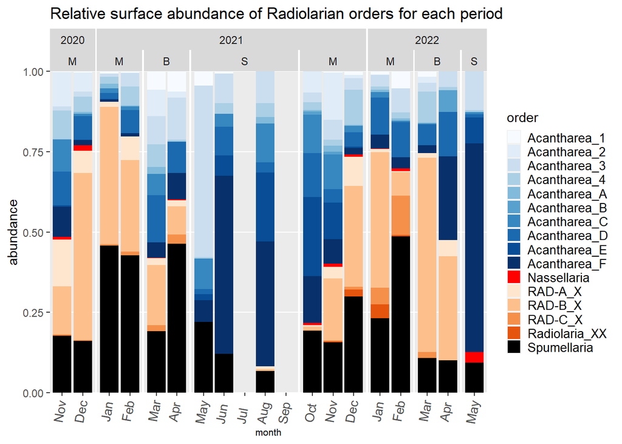

```r
PlotAbundance(abund, c("surface", "all"), "Relative surface abundance of Radiolarian orders for each period")
```

## Diversité de Shannon et indice de Pielou

Le tableau `div`va permettre de calculer et de représenter des indices de diversité écologique en fonction des mois.

La diversité de Shannon et l’équitabilité de Pielou sont calculées à partir de l’abondance des OTUs dans chaque échantillon.

```r
div <- data.frame("Shannon" = diversity(t(OTU[-1]), MARGIN = 1, index = "shannon"))
div$Pielou <- div$Shannon / log(rowSums(t(OTU[-1]) != 0))
```

|  | Shannon | Pielou |
| --- | --- | --- |
| A_201125_1 | 3.375789 | 0.8349608 |
| A_201125_2 | 3.380885 | 0.8362212 |
| A_201216_1 | 3.201064 | 0.8564332 |
| A_201216_2 | 3.091723 | 0.8499380 |
| A_201230_1 | 2.129405 | 0.5697147 |
| A_201230_2 | 2.189251 | 0.5785258 |

Des colonnes contenant le mois, la période et l’année associés à chaque échantillon sont rajoutées.

```r
div$month <- GetMonth(rownames(div))
div$period <- GetPeriod(rownames(div))
div$year <- paste("20", substr(rownames(div), 3, 4), sep = "")
```

Les NA sont retirés (juste une valeur de Pielou), puis les échantillons sont regroupés par mois.

```r
div <- drop_na(div)

div <- div %>%
  group_by(month, period, year) %>%
  summarize(across(c(Shannon, Pielou), mean))
```

| month | period | year | Shannon | Pielou |
| --- | --- | --- | --- | --- |
| 1 | M_1_2021 | 2021 | 2.512421 | 0.6987518 |
| 1 | M_1_2022 | 2022 | 2.647133 | 0.7963894 |
| 2 | M_1_2021 | 2021 | 2.176382 | 0.6373307 |
| 2 | M_1_2022 | 2022 | 2.901272 | 0.8205193 |
| 3 | B_2021 | 2021 | 1.983481 | 0.7805463 |
| 3 | B_2022 | 2022 | 1.596583 | 0.5349449 |

Des valeurs nulles sont rajoutées en juillet et septembre.

```r
div <- rbind(div, data.frame(month = "7", period = "S_2021", year = "2021", Shannon = 0, Pielou = 0))
div <- rbind(div, data.frame(month = "9", period = "S_2021", year = "2021", Shannon = 0, Pielou = 0))
```

La période est ordonnée en facteur, le nom de mois est rajouté puis tout le tableau est converti au format long pour la représentation graphique.

```r
div$period <- factor(div$period, levels = names(period_labs))

div$month_str <- months_equi$month_str[match(div$month, months_equi$month)]
div$month_str <- factor(div$month_str, levels = months_equi$month_str)

div <- gather(div, "index", "value", -c(1, 2, 3, 6))
```

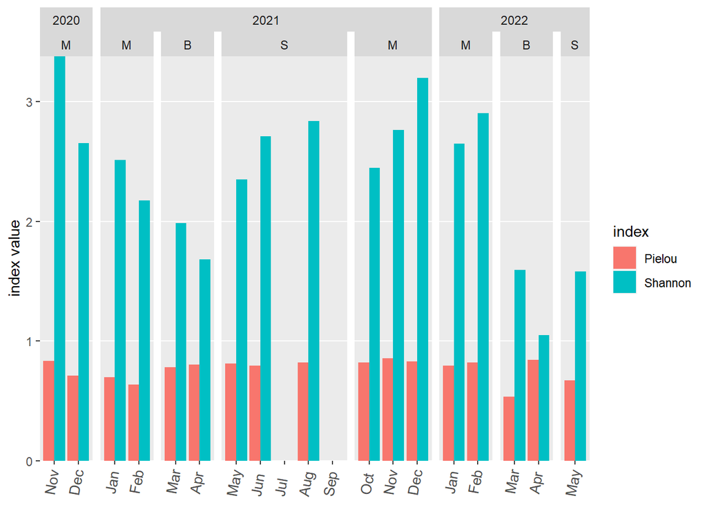

```r
ggplot(data = div, aes(x = month_str, y = value, fill = index)) +
  geom_col(position = position_dodge()) +
  facet_nested(cols = vars(year, period), scales = "free", space = "free", labeller = labeller(period = period_labs)) +
  scale_y_continuous(expand = c(0, 0)) +
  ylab("index value") +
  theme(axis.text.x = element_text(size = 10, angle = 80, hjust = 0, vjust = 0),
        axis.title.x = element_blank(),
        panel.grid.major.x = element_blank(),
        panel.grid.minor.x = element_blank(),
        panel.grid.minor.y = element_blank())
```

## Courbes d’abondance relative

L’abondance relative moyenne par mois de chaque ordre est représentée individuellement. L’abondance en surface est en bleu et celle à la dcm (quand elle a été mesurée) en vert.

```r
ab_plots <- lapply(unique(abund$order), function(i) {
  ggplot(subset(abund, order == i), aes(x = month_str, y = value, fill = depth)) +
    geom_bar(stat = "identity") +
    facet_nested(cols = vars(year, period), scales = "free", space = "free", labeller = labeller(period = period_labs)) +
    theme(axis.text.x = element_text(size = 7, angle = 80, hjust = 0, vjust = 0),
          axis.title.x = element_blank(),
          axis.text.y = element_text(size = 7),
          axis.title.y = element_blank(),
          legend.position = "none",
          panel.spacing = unit(0.1,'lines'),
          panel.grid.major.x = element_blank(),
          panel.grid.minor.y = element_blank(),
          strip.text.x = element_text(size = 7)) +
    scale_y_continuous(limits = c(0, 1), breaks = c(0, 0.25, 0.5, 0.75, 1), expand = c(0, 0)) +
    scale_fill_manual(values = depth_palette) +
    ggtitle(i)
})
```

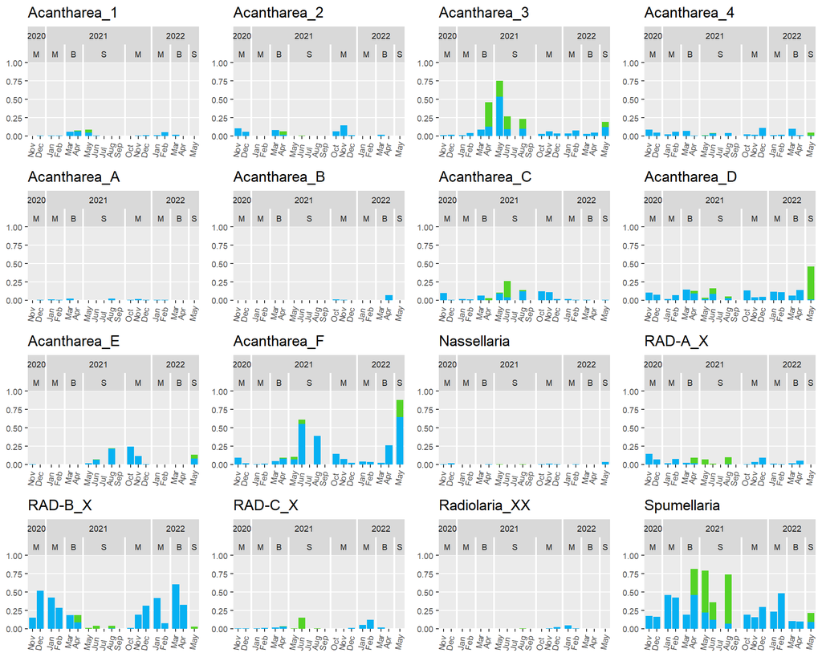

```r
grid.arrange(grobs = ab_plots, ncol = 4, nrow = 4)
```

## Courbes de paramètres physicochimiques

La valeur de chaque paramètre est représentée en fonction de la date de l’échantillonnage. Les points bleus correspondent à la valeur en surface et les points verts à la dcm.

Le tableau metadata contient la date, la période, la profondeur et la valeur de chaque paramètre associée (seul le réplicat `a` est gardé car les valeurs sont identiques entre réplicats).

```r
metadata = drop_na(META)
metadata <- subset(metadata, sample == "a")
metadata$year <- paste("20", metadata$year, sep = "")
metadata <- cbind(period = GetPeriod(metadata$sample_id), metadata)
```

|  | period | sample_id | year | month | day | date | sample | depth | temp | salinity | chl | PO4 | Silica | TIN | wind_speed | PAR | UV |
| --- | --- | --- | --- | --- | --- | --- | --- | --- | --- | --- | --- | --- | --- | --- | --- | --- | --- |
| 1 | M_2_2020 | A_201125_1 | 2020 | 11 | 25 | 25/11/2020 | a | surface | 25.4452 | 40.5090 | 0.2349598 | 0.03 | 0.32 | 0.2501435 | 3.3 | 366 | 17 |
| 3 | M_2_2020 | A_201216_1 | 2020 | 12 | 16 | 16/12/2020 | a | surface | 24.8394 | 40.8433 | 0.2283674 | 0.04 | 0.31 | 0.2900367 | 0.9 | 97 | 9 |
| 5 | M_2_2020 | A_201230_1 | 2020 | 12 | 30 | 30/12/2020 | a | surface | 23.8268 | 40.9096 | 0.2413977 | 0.02 | 0.43 | 0.4335441 | 6.0 | 180 | 11 |
| 7 | M_1_2021 | A_210107_1 | 2021 | 1 | 7 | 07/01/2021 | a | surface | 23.4476 | 40.8018 | 0.2483686 | 0.07 | 0.37 | 0.4271946 | 4.5 | 190 | 11 |
| 9 | M_1_2021 | A_210127_1 | 2021 | 1 | 27 | 27/01/2021 | a | surface | 22.8755 | 40.8076 | 0.1959743 | 0.03 | 0.51 | 0.5155117 | 3.6 | 137 | 10 |
| 11 | M_1_2021 | A_210210_1 | 2021 | 2 | 10 | 10/02/2021 | a | surface | 22.5235 | 40.7906 | 0.1591633 | 0.05 | 0.38 | 0.4083117 | 4.8 | 262 | 14 |

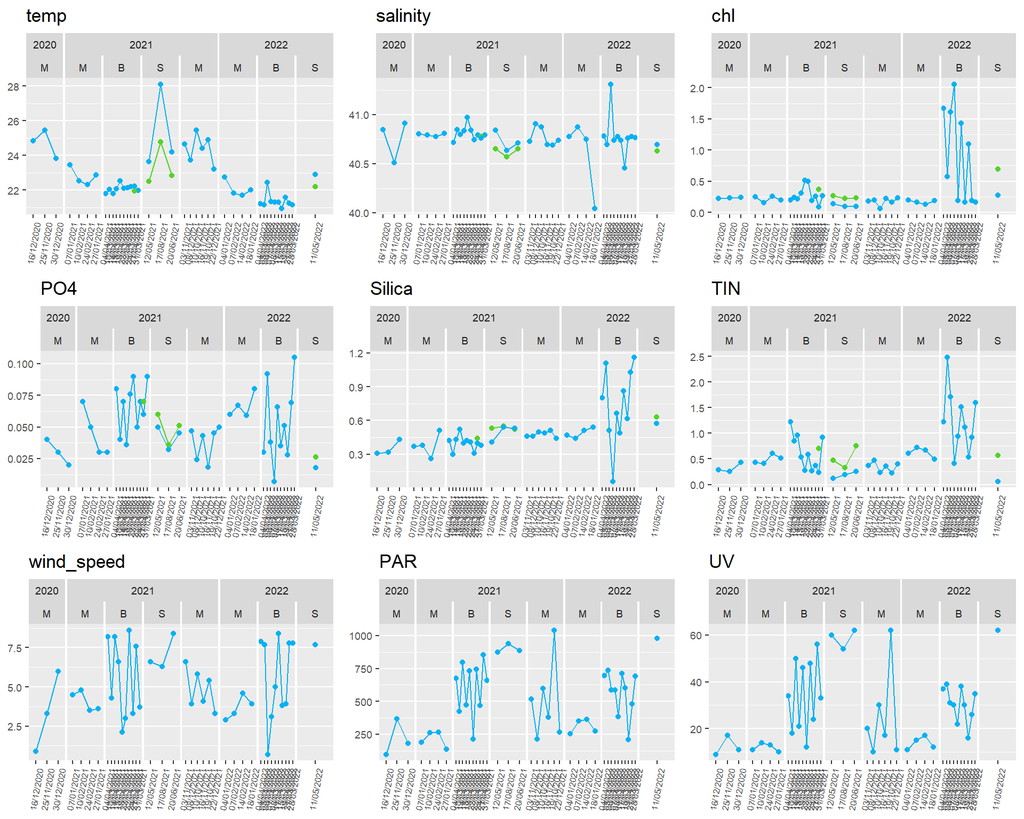

```r
var_plots <- lapply(unique(colnames(metadata))[-c(1:8)], function(i) {
  ggplot(data = metadata, aes(x = date, y = .data[[i]], group = depth, color = depth)) +
    geom_line() +
    geom_point() +
    facet_nested(cols = vars(year, period), scales = "free", labeller = labeller(period = period_labs)) +
    theme(axis.text.x = element_text(angle = 80, size = 6, hjust = 0, vjust = 0),
          axis.title.x = element_blank(),
          axis.text.y = element_text(size = 7),
          axis.title.y = element_blank(),
          legend.position = "none",
          panel.spacing = unit(0.1,'lines'),
          panel.grid.major.x = element_blank(),
          strip.text.x = element_text(size = 7)) +
    scale_color_manual(values = depth_palette) +
    ggtitle(i)
})
```

## ACP

Les échantillons sont représentés par des points colorés en fonction de la profondeur.

```r
PC_data <- drop_na(META)
PC_data <- cbind(period = GetPeriod(PC_data$sample_id), PC_data)
```

| period | sample_id | year | month | day | date | sample | depth | temp | salinity | chl | PO4 | Silica | TIN | wind_speed | PAR | UV |
| --- | --- | --- | --- | --- | --- | --- | --- | --- | --- | --- | --- | --- | --- | --- | --- | --- |
| M_2_2020 | A_201125_1 | 20 | 11 | 25 | 25/11/2020 | a | surface | 25.4452 | 40.5090 | 0.2349598 | 0.03 | 0.32 | 0.2501435 | 3.3 | 366 | 17 |
| M_2_2020 | A_201125_2 | 20 | 11 | 25 | 25/11/2020 | b | surface | 25.4452 | 40.5090 | 0.2349598 | 0.03 | 0.32 | 0.2501435 | 3.3 | 366 | 17 |
| M_2_2020 | A_201216_1 | 20 | 12 | 16 | 16/12/2020 | a | surface | 24.8394 | 40.8433 | 0.2283674 | 0.04 | 0.31 | 0.2900367 | 0.9 | 97 | 9 |
| M_2_2020 | A_201216_2 | 20 | 12 | 16 | 16/12/2020 | b | surface | 24.8394 | 40.8433 | 0.2283674 | 0.04 | 0.31 | 0.2900367 | 0.9 | 97 | 9 |
| M_2_2020 | A_201230_1 | 20 | 12 | 30 | 30/12/2020 | a | surface | 23.8268 | 40.9096 | 0.2413977 | 0.02 | 0.43 | 0.4335441 | 6.0 | 180 | 11 |
| M_2_2020 | A_201230_2 | 20 | 12 | 30 | 30/12/2020 | b | surface | 23.8268 | 40.9096 | 0.2413977 | 0.02 | 0.43 | 0.4335441 | 6.0 | 180 | 11 |

La fonction `PCAForPeriod` permet de réaliser une ACP uniquement sur la période voulue.

```r
PCAForPeriod = function(p, title = paste(p, collapse = " - ")) {
  data = subset(PC_data, period %in% p)
  # Enlever colonnes avec une variance nulle
  pca <- prcomp(data[9:17][, which(apply(data[9:17], 2, var) != 0)], scale = TRUE)

  a <- autoplot(pca, data = data, size = 2, colour = "depth", loadings = TRUE,
                loadings.label = TRUE, loadings.label.colour = "black")
  return(a + ggtitle(title) + scale_color_manual(values = depth_palette))
}
```

Une ACP est réalisée pour chaque période sans distinction d’année, ainsi qu’une pour la totalité des données.

```r
mixing_PCA <- PCAForPeriod(c("M_2_2020", "M_1_2021", "M_2_2021", "M_1_2022"), "mixing")
bloom_PCA <- PCAForPeriod(c("B_2021", "B_2022"), "bloom")
strat_PCA <- PCAForPeriod(c("S_2021", "S_2022"), "stratification")
all_PCA <- PCAForPeriod(unique(PC_data$period), "all periods")
```

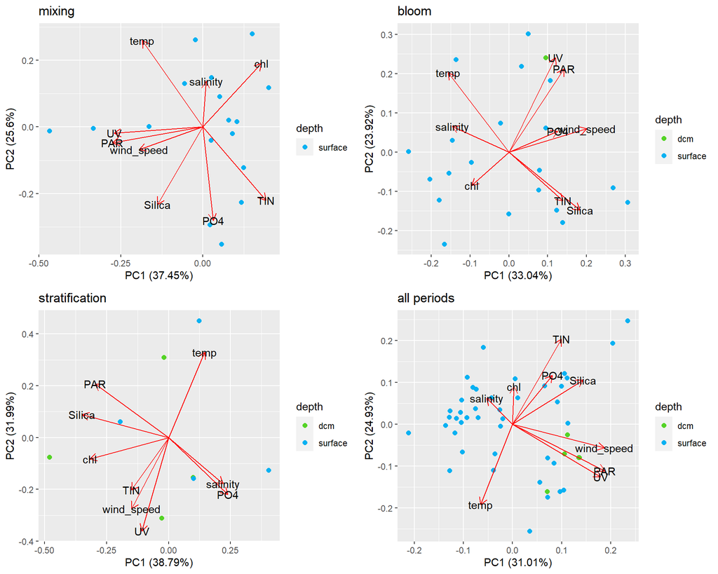

```r
ggarrange(mixing_PCA, bloom_PCA, strat_PCA, all_PCA, ncol = 2, nrow = 2)
```

## Corrélogrammes

La table de corrélation est formée à partir de l’abondance de chaque OTU dans chaque échantillon.

```r
correlation_table <- gather(OTU, "sample", "value", -1)
correlation_table$X <- paste("OTU_", sprintf("%03d", seq(1, 531, 1)), sep = "")
```

| X | sample | value |
| --- | --- | --- |
| OTU_001 | A_201125_1 | 0 |
| OTU_002 | A_201125_1 | 25 |
| OTU_003 | A_201125_1 | 0 |
| OTU_004 | A_201125_1 | 0 |
| OTU_005 | A_201125_1 | 142 |
| OTU_006 | A_201125_1 | 0 |

Des colonnes contenant l’Ordre, le group et la période sont rajoutées.

```r
correlation_table$order <- OTU_to_group$Order[match(correlation_table$X, OTU_to_group$OTU)]
correlation_table$group <- OTU_to_group$group[match(correlation_table$X, OTU_to_group$OTU)]
correlation_table$period <- GetPeriod(correlation_table$sample)
```

| X | sample | value | order | group | period |
| --- | --- | --- | --- | --- | --- |
| OTU_001 | A_201125_1 | 0 | Spumellaria | Spumellaria | M_2_2020 |
| OTU_002 | A_201125_1 | 25 | RAD-B_X | RAD-B | M_2_2020 |
| OTU_003 | A_201125_1 | 0 | RAD-B_X | RAD-B | M_2_2020 |
| OTU_004 | A_201125_1 | 0 | Spumellaria | Spumellaria | M_2_2020 |
| OTU_005 | A_201125_1 | 142 | RAD-B_X | RAD-B | M_2_2020 |
| OTU_006 | A_201125_1 | 0 | Spumellaria | Spumellaria | M_2_2020 |

Toutes les valeurs de paramètres physicochimiques sont rajoutées aux échantillons correspondants.

```r
correlation_table <- cbind(correlation_table, META[match(correlation_table$sample, META$sample_id), ][7:16])
correlation_table <- drop_na(correlation_table)
```

|  | X | sample | value | order | group | period | depth | temp | salinity | chl | PO4 | Silica | TIN |
| --- | --- | --- | --- | --- | --- | --- | --- | --- | --- | --- | --- | --- | --- |
| 1 | OTU_001 | A_201125_1 | 0 | Spumellaria | Spumellaria | M_2_2020 | surface | 25.4452 | 40.509 | 0.2349598 | 0.03 | 0.32 | 0.2501435 |
| 1.1 | OTU_002 | A_201125_1 | 25 | RAD-B_X | RAD-B | M_2_2020 | surface | 25.4452 | 40.509 | 0.2349598 | 0.03 | 0.32 | 0.2501435 |
| 1.2 | OTU_003 | A_201125_1 | 0 | RAD-B_X | RAD-B | M_2_2020 | surface | 25.4452 | 40.509 | 0.2349598 | 0.03 | 0.32 | 0.2501435 |
| 1.3 | OTU_004 | A_201125_1 | 0 | Spumellaria | Spumellaria | M_2_2020 | surface | 25.4452 | 40.509 | 0.2349598 | 0.03 | 0.32 | 0.2501435 |
| 1.4 | OTU_005 | A_201125_1 | 142 | RAD-B_X | RAD-B | M_2_2020 | surface | 25.4452 | 40.509 | 0.2349598 | 0.03 | 0.32 | 0.2501435 |
| 1.5 | OTU_006 | A_201125_1 | 0 | Spumellaria | Spumellaria | M_2_2020 | surface | 25.4452 | 40.509 | 0.2349598 | 0.03 | 0.32 | 0.2501435 |

La fonction `ComputeCorrelation()` calcule une matrice de corrélation entre deux tables contenant la variable d’intérêt en colonnes et les observations en lignes. Un tableau vide est créé avec en lignes et en colonnes les colonnes des deux tables fournies, puis la corrélation entre chacun des couples est calculée et assignée à la cellule correspondante.

```r
ComputeCorrelation = function(ind_table, var_table) {
  df <- data.frame(matrix(NA, nrow = ncol(ind_table), ncol = ncol(var_table)))
  colnames(df) <- colnames(var_table)
  rownames(df) <- colnames(ind_table)

  for (var in colnames(df)) {
    for (ind in rownames(df)) {
      df[ind, var] <- round(cor(ind_table[ind], var_table[var]), 2)
    }
  }

  return(df)
}
```

Par exemple, la table des OTUs :

|  | OTU_001 | OTU_002 | OTU_003 | OTU_004 | OTU_005 | OTU_006 | OTU_007 | OTU_008 | OTU_009 | OTU_010 |
| --- | --- | --- | --- | --- | --- | --- | --- | --- | --- | --- |
| A_201125_1 | 0 | 25 | 0 | 0 | 142 | 0 | 50 | 24 | 0 | 33 |
| A_201125_2 | 0 | 31 | 0 | 13 | 103 | 22 | 43 | 30 | 19 | 29 |
| A_201216_1 | 21 | 30 | 16 | 6 | 275 | 0 | 51 | 46 | 0 | 45 |
| A_201216_2 | 8 | 31 | 11 | 6 | 112 | 0 | 25 | 44 | 0 | 17 |
| A_201230_1 | 24 | 0 | 620 | 5 | 1147 | 0 | 53 | 29 | 0 | 64 |
| A_201230_2 | 13 | 0 | 681 | 3 | 869 | 0 | 58 | 21 | 0 | 35 |

et la table des variables environnementales :

| temp | salinity | chl | PO4 | Silica | TIN | wind_speed | PAR | UV |
| --- | --- | --- | --- | --- | --- | --- | --- | --- |
| 25.4452 | 40.5090 | 0.2349598 | 0.03 | 0.32 | 0.2501435 | 3.3 | 366 | 17 |
| 25.4452 | 40.5090 | 0.2349598 | 0.03 | 0.32 | 0.2501435 | 3.3 | 366 | 17 |
| 24.8394 | 40.8433 | 0.2283674 | 0.04 | 0.31 | 0.2900367 | 0.9 | 97 | 9 |
| 24.8394 | 40.8433 | 0.2283674 | 0.04 | 0.31 | 0.2900367 | 0.9 | 97 | 9 |
| 23.8268 | 40.9096 | 0.2413977 | 0.02 | 0.43 | 0.4335441 | 6.0 | 180 | 11 |
| 23.8268 | 40.9096 | 0.2413977 | 0.02 | 0.43 | 0.4335441 | 6.0 | 180 | 11 |

Donnent la matrice de corrélation suivante :

|  | temp | salinity | chl | PO4 | Silica | TIN | wind_speed | PAR | UV |
| --- | --- | --- | --- | --- | --- | --- | --- | --- | --- |
| OTU_001 | -0.04 | 0.01 | -0.16 | 0.16 | -0.13 | 0.01 | -0.04 | -0.02 | -0.03 |
| OTU_002 | -0.26 | -0.02 | -0.12 | 0.35 | 0.65 | 0.33 | 0.23 | 0.03 | -0.01 |
| OTU_003 | 0.08 | 0.17 | -0.12 | -0.21 | -0.24 | -0.10 | -0.14 | -0.42 | -0.38 |
| OTU_004 | -0.04 | 0.01 | -0.16 | 0.16 | -0.13 | 0.01 | -0.05 | -0.01 | -0.03 |
| OTU_005 | 0.20 | 0.14 | -0.10 | -0.23 | -0.14 | -0.14 | -0.11 | -0.38 | -0.33 |
| OTU_006 | 0.21 | -0.16 | -0.07 | -0.11 | 0.03 | -0.11 | 0.04 | 0.18 | 0.16 |

Les paramètres graphiques du plot sont définis (permettent d’avoir une légende toujours comrise entre -1 et 1 et avec les mêmes couleurs).

```r
breaks_list <- seq(-1, 1, by = 0.01)
colors_list <- colorRampPalette(rev(brewer.pal(n = 7, name = "RdYlBu")))(length(breaks_list))
```

La fonction `PlotOTUCorr()` prend en argument une table de corrélation, ainsi que les périodes et la profondeur voulues. Une matrice de corrélation est formée en faisant appel à la fonction `ComputeCorrelation()`, puis une colonne avec le groupe est rajoutée afin de regrouper les OTUs.  
La heatmap qui représente visuellement les valeurs de corrélation est construite à l’aide du package `pheatmap`. Les OTUs sont en colonne, regroupés taxonomiquement, et les paramètres physicochimiques en ligne.

```r
PlotOTUCorr = function(table, periods, depths) {
  table <- subset(table, period %in% periods & depth %in% depths)
  corr <- ComputeCorrelation(as.data.frame(df_mat(table, sample, X, value)),
                             table[match(unique(table$sample), table$sample), ][8:16])
  corr <- cbind(group = table$group[match(rownames(corr), table$X)], corr)
  corr <- corr[order(corr$group), ]

  pheatmap(t(corr[-1]),
           annotation_col = corr[1],
           annotation_colors = list(group = group_palette),
           color = colors_list,
           breaks = breaks_list,
           main = paste(paste(periods, collapse = " - "), " / ", paste(depths, collapse = " - ")),
           fontsize = 8,
           fontsize_row = 8,
           show_colnames = FALSE,
           cluster_cols = FALSE,
           cluster_rows = FALSE)
}
```

Les résultats de cette fonction sont les suivants : une heatmap pour le mixing, une pour le bloom, une pour la stratification en surface et une pour la stratification en dcm.

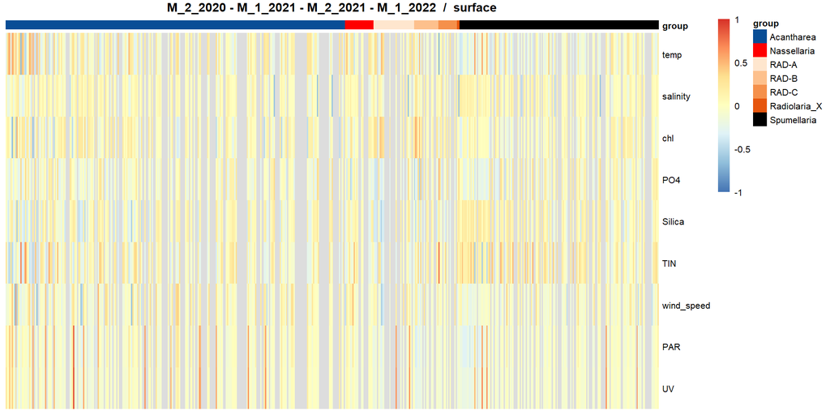

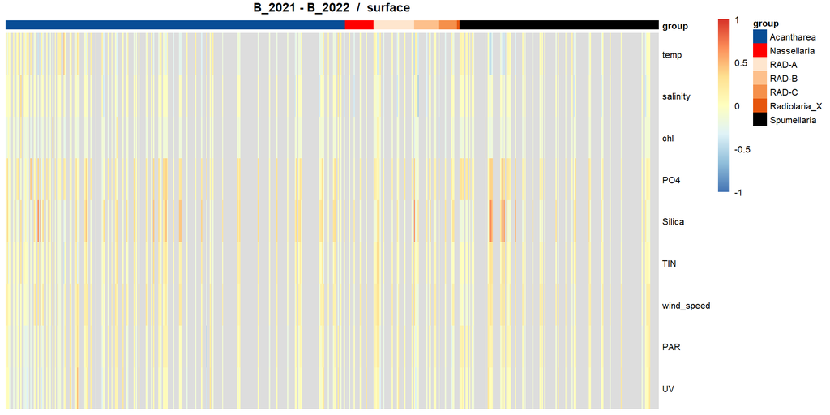

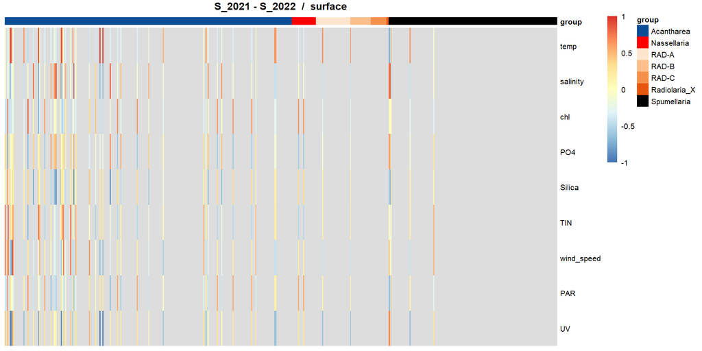

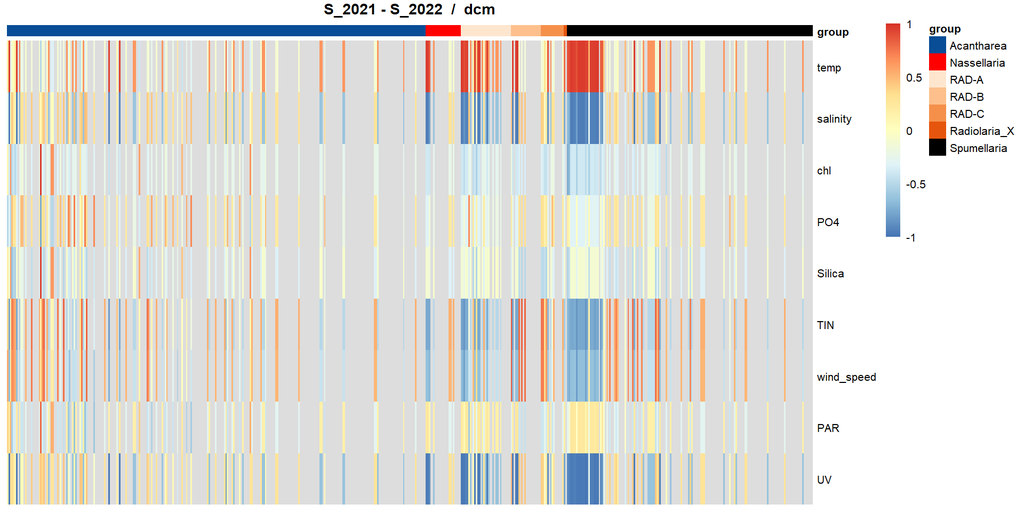

La fonction `plotOrderCorr()` fait la même chose que `PlotOTUCorr()` mais pour la corrélation des Ordres de Radiolaires entre eux.

```r
PlotOrderCorr = function(table, periods, depths) {
  table <- subset(table, period %in% periods & depth %in% depths) %>%
    group_by(sample, order, period, depth, temp, salinity, chl, PO4, Silica, TIN, wind_speed, PAR, UV) %>%
    summarize(across(value, sum))
  corr <- ComputeCorrelation(as.data.frame(df_mat(table, sample, order, value)),
                             as.data.frame(df_mat(table, sample, order, value)))

  pheatmap(corr,
           color = colors_list,
           breaks = breaks_list,
           main = paste(paste(periods, collapse = " - "), " / ", paste(depths, collapse = " - ")),
           fontsize = 8,
           fontsize_row = 8,
           cluster_cols = FALSE,
           cluster_rows = FALSE)
}
```

Les résultats sont les suivants : (mêmes caractéristiques que pour les plots d’OTU)

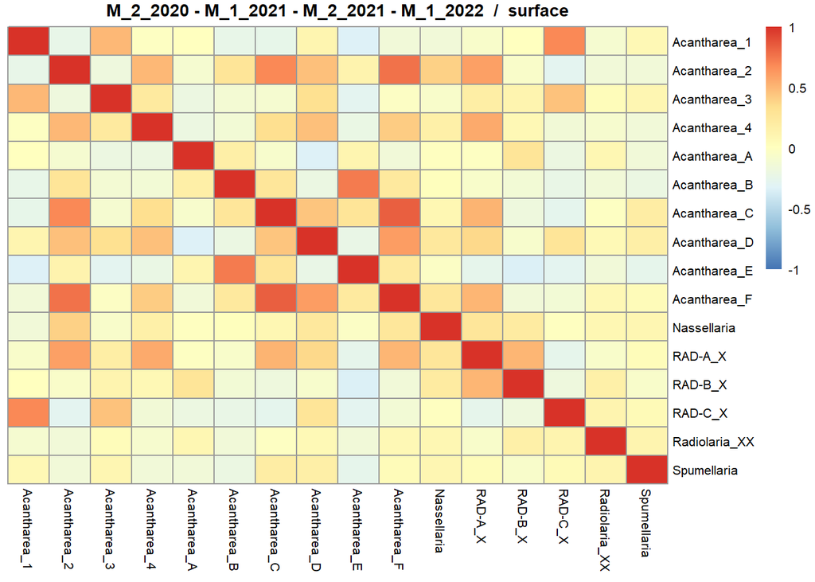

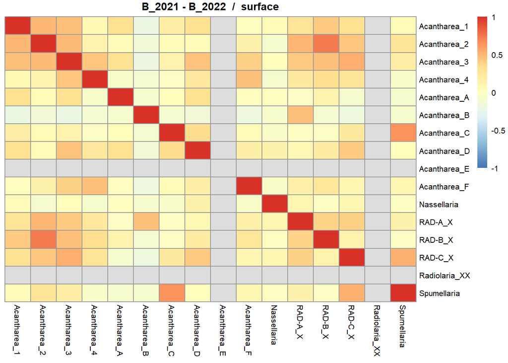

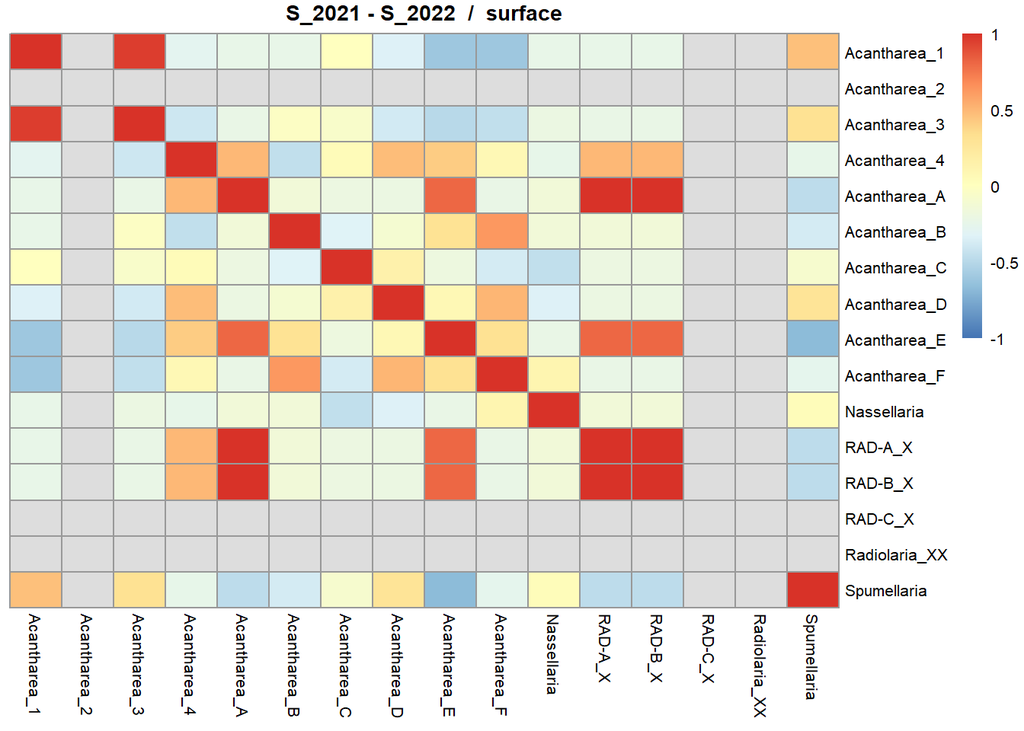

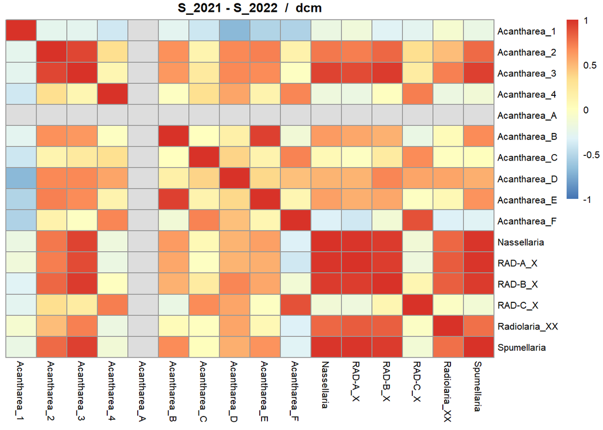

La fonction`plotVariableCorr()` montre la corrélation entre les variables physicochimiques.

```r
PlotVariableCorr = function(table, periods, depths) {
  table <- subset(table, period %in% periods & depth %in% depths)
  corr <- ComputeCorrelation(table[match(unique(table$sample), table$sample), ][8:16],
                             table[match(unique(table$sample), table$sample), ][8:16])
  pheatmap(corr,
           color = colors_list,
           breaks = breaks_list,
           main = paste(paste(periods, collapse = " - "), " / ", paste(depths, collapse = " - ")),
           fontsize = 8,
           fontsize_row = 8,
           cluster_cols = FALSE,
           cluster_rows = FALSE)
}
```

Les résultats sont les suivants : (mêmes caractéristiques que pour les plots d’OTU et d’Ordres)

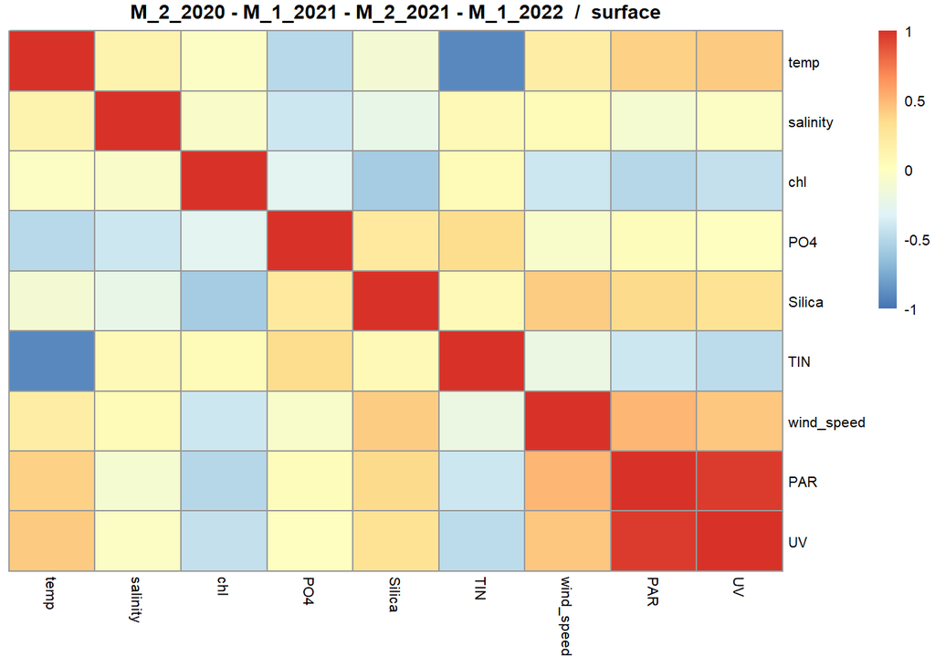

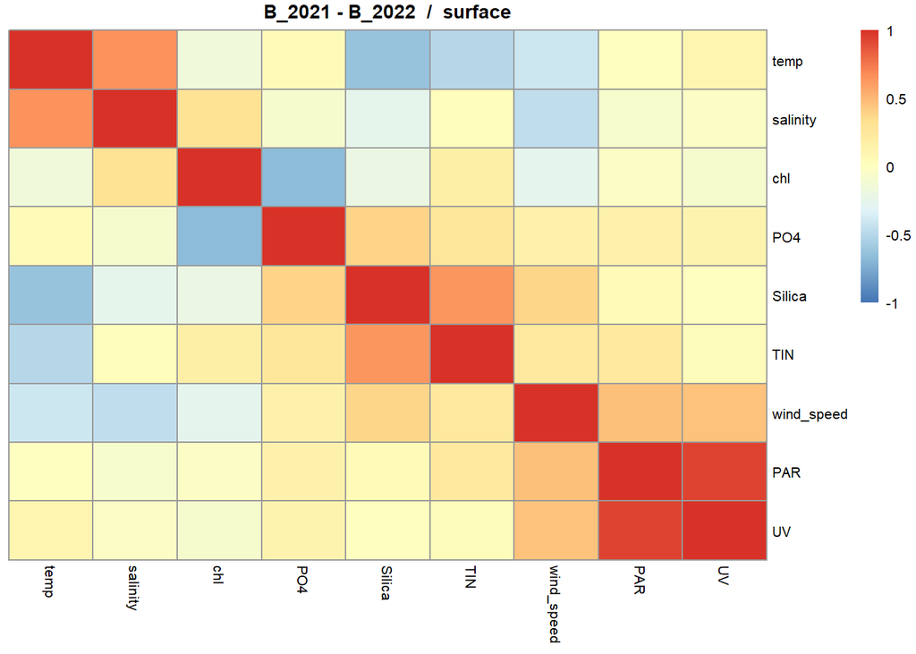

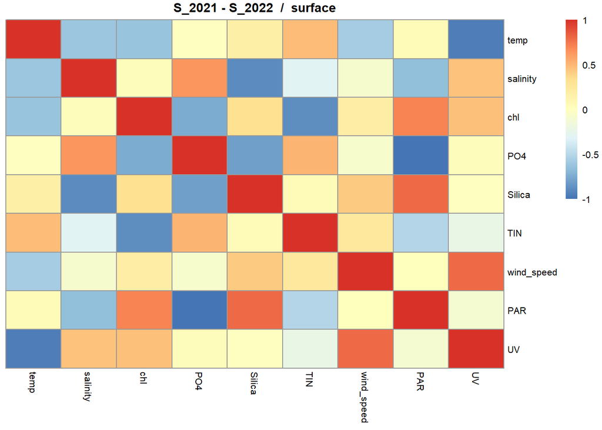

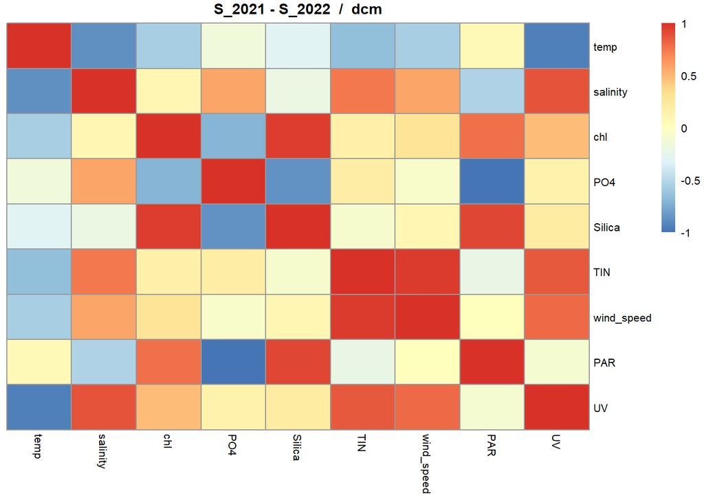